# Amino Acid Physicochemical Properties

protein-r-foundations — Final Project (Project 0-B)

Author

Afraim Mario Mokhtar Boshra

Published

September 17, 2026

## Purpose

This project applies R and ggplot2 to the analysis and visualization of physicochemical properties of the 20 canonical amino acids. It serves as Project 0-B of the Computational Proteomics Master Plan and is intended as a foundational exercise in reproducible biological data analysis rather than as a research study. Amino acid property data are obtained from the Peptides R package and inspected before being assembled into an analysis-ready table, using the Kyte–Doolittle hydropathy scale for hydrophobicity and the Bjellqvist pKa scale for theoretical isoelectric-point calculation. The resulting visualizations examine the distribution of amino-acid hydrophobicity, the relationship between hydrophobicity and theoretical pI, the physicochemical composition of the canonical EGFR sequence, and local hydrophobicity across the annotated EGFR kinase domain.

## Setup

```r
knitr::opts_chunk$set(dev = "png", dev.args = list(type = "cairo"))
library(ggplot2)
library(Peptides)
library(ggrepel)
library(dplyr)
library(tibble)
library(readr)
library(gridExtra)
data("AAdata")
```

## Inspect before you build

Before constructing the analysis table, the relevant Peptides functions and data objects were inspected to verify their arguments, output structure, and property definitions. Particular attention was given to the hydrophobicity scale, theoretical pI calculation, amino-acid list, and the package’s amino-acid property data. This inspection step was used to distinguish package-derived reference values from calculated sequence-level properties before constructing the downstream analyses.

```r
Peptides::charge("MTKRCF") # charge(seq, pH = 7, pKscale = "Lehninger")
```

```
[1] 1.935711
```

```r
# where it requires an amino-acids sequence

Peptides::aaList()
```

```
 [1] "A" "C" "D" "E" "F" "G" "H" "I" "K" "L" "M" "N" "P" "Q" "R" "S" "T" "V" "W"
[20] "Y"
```

```r
args(hydrophobicity)
```

```
function (seq, scale = "KyteDoolittle")
NULL
```

```r
pI("MTKRCF") # pI(seq, pKscale = "EMBOSS") where it requires an amino-acids sequence,
```

```
[1] 9.833244
```

```r
# must be one of "Bjellqvist", "EMBOSS", "Murray", "Sillero", "Solomon", etc..

str(AAdata$Hydrophobicity$KyteDoolittle)
```

```
 Named num [1:20] 1.8 -4.5 -3.5 -3.5 2.5 -3.5 -3.5 -0.4 -3.2 4.5 ...
 - attr(*, "names")= chr [1:20] "A" "R" "N" "D" ...
```

## Data and Property Definitions

```r
# Amino acid
amino_acids <- Peptides::aaList()
aa_name <- c("A"="Alanine","C"="Cysteine",
             "D"="Aspartic acid","E"="Glutamic acid",
             "F"="Phenylalanine","G"="Glycine",
             "H"="Histidine","I"="Isoleucine",
             "K"="Lysine","L"="Leucine",
             "M"="Methionine","N"="Asparagine",
             "P"="Proline","Q"="Glutamine",
             "R"="Arginine","S"="Serine",
             "T"="Threonine","V"="Valine",
             "W"="Tryptophan","Y"="Tyrosine")

# Hydrophobicity (Kyte–Doolittle)
aa_hydrophob <- Peptides::hydrophobicity(amino_acids, scale = "KyteDoolittle")

# pI pKscale of Bjellqvist
aa_pI <- Peptides::pI(amino_acids, pKscale = "Bjellqvist")

# Charge classification at pH 7.4
aa_charge <- c("A"="Uncharged (Neutral)","C"="Uncharged (Neutral)",
               "D"="Negatively Charged (Acidic)","E"="Negatively Charged (Acidic)",
               "F"="Uncharged (Neutral)","G"="Uncharged (Neutral)",
               "H"="Positively Charged (Basic)","I"="Uncharged (Neutral)",
               "K"="Positively Charged (Basic)","L"="Uncharged (Neutral)",
               "M"="Uncharged (Neutral)", "N"="Uncharged (Neutral)",
               "P"="Uncharged (Neutral)","Q"="Uncharged (Neutral)",
               "R"="Positively Charged (Basic)","S"="Uncharged (Neutral)",
               "T"="Uncharged (Neutral)","V"="Uncharged (Neutral)",
               "W"="Uncharged (Neutral)","Y"="Uncharged (Neutral)")


aa_table_frame <- data.frame(amino_acids, aa_hydrophob, aa_pI,
                             aa_name = aa_name[amino_acids],
                             aa_charge = aa_charge[amino_acids])
```

## Visualizations

### Hydrophobicity of the 20 Canonical Amino Acids

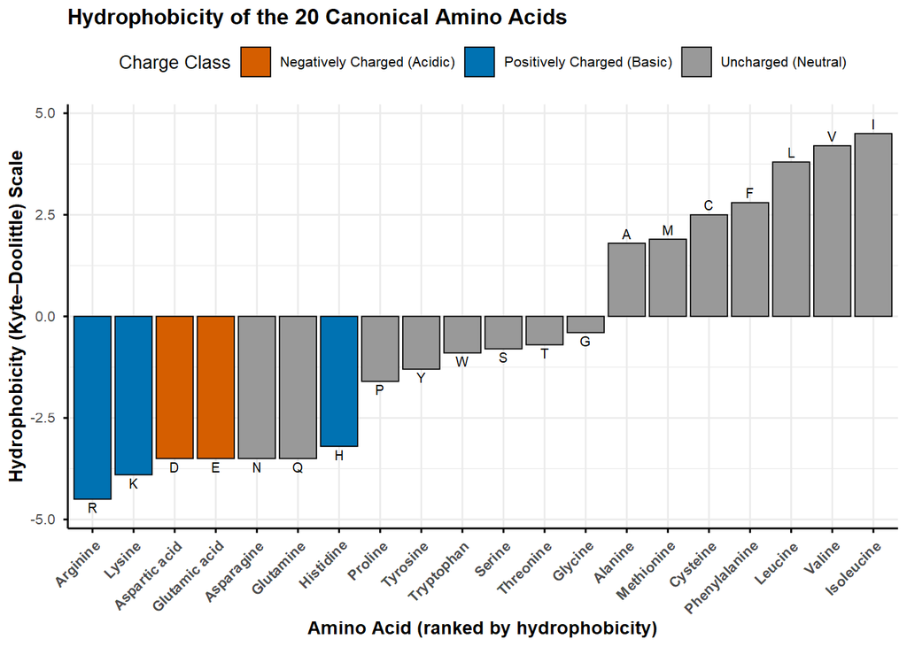

```r
charge_colors <- c("Negatively Charged (Acidic)" = "#D55E00",
                   "Uncharged (Neutral)"         = "#999999",
                   "Positively Charged (Basic)"  = "#0072B2")

aa_plot <- aa_table_frame |>
  mutate(aa_name = factor(aa_name, levels = aa_name[order(aa_hydrophob)]))

plot1 <- ggplot(aa_plot, aes(aa_name, aa_hydrophob, label = amino_acids))

plot1 +
  geom_col(aes(fill = aa_charge), width = 0.9, color = "black", linewidth = 0.3) +
  geom_text(aes(vjust = ifelse(aa_hydrophob >= 0, -0.4, 1.4)), size = 2.7) +
  scale_fill_manual(values = charge_colors) +
  scale_y_continuous(expand = expansion(mult = c(0.08, 0.08))) +
  labs(x = "Amino Acid (ranked by hydrophobicity)",
       y = "Hydrophobicity (Kyte–Doolittle) Scale",
       fill = "Charge Class",
       title = "Hydrophobicity of the 20 Canonical Amino Acids") +
  theme_minimal(base_size = 10) +
  theme(plot.title    = element_text(face = "bold"),
        axis.title    = element_text(face = "bold"),
        axis.text.x   = element_text(angle = 45, hjust = 1, face = "bold"),
        axis.line     = element_line(linewidth = 0.5),
        axis.ticks    = element_line(linewidth = 0.5),
        legend.position = "top", legend.direction = "horizontal")
```

### Relationship Between Hydrophobicity and Isoelectric Point

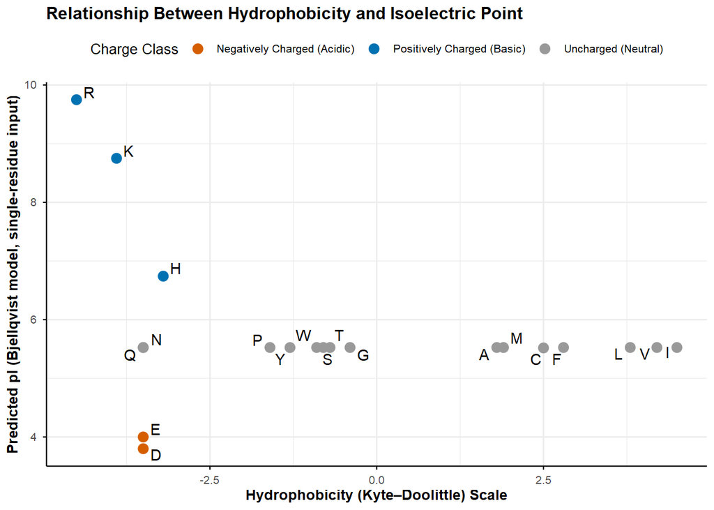

```r
charge_colors <- c("Negatively Charged (Acidic)" = "#D55E00",
                   "Uncharged (Neutral)"  = "#999999",
                   "Positively Charged (Basic)" = "#0072B2")

plot2 <- aa_table_frame |> ggplot(aes(aa_hydrophob, aa_pI, label = amino_acids))
plot2 + theme_minimal(base_size = 10) + geom_point(aes(col = aa_charge),
                                                   size = 3) +
  geom_text_repel(col= "black") +
  xlab("Hydrophobicity (Kyte–Doolittle) Scale") +
  ylab("Predicted pI (Bjellqvist model, single-residue input)") +
  ggtitle("Relationship Between Hydrophobicity and Isoelectric Point") +
  labs(col = "Charge Class") + scale_color_manual(values = charge_colors) +
  theme(plot.title    = element_text(face = "bold"),
        axis.title    = element_text(face = "bold"),
        axis.line     = element_line(linewidth = 0.4),
        axis.ticks    = element_line(linewidth = 0.4),
        legend.position = "top", legend.direction = "horizontal")
```

## EGFR Sequence Analysis

The canonical human EGFR sequence was analyzed to demonstrate how amino-acid physicochemical properties can be examined in the context of a real protein sequence. Residue composition was summarized across the physicochemical categories provided by `Peptides::aaComp()`, while the annotated kinase domain (residues 712–979) was analyzed using a sliding-window Kyte–Doolittle hydropathy profile.

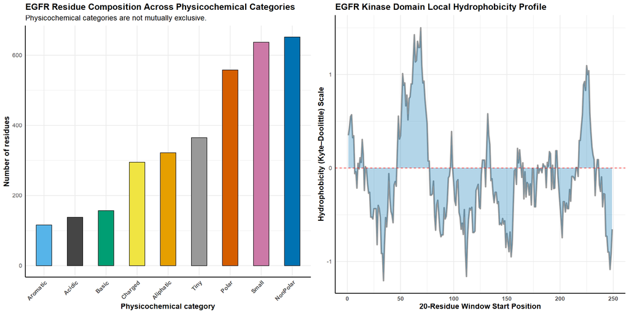

```r
fasta_line <- read_lines("https://rest.uniprot.org/uniprotkb/P00533.fasta")
egfr_seq <- fasta_line[2:length(fasta_line)]
egfr <- paste(egfr_seq, collapse = "")
stopifnot(nchar(egfr) == 1210)


safe_colors <- c("Acidic" = "#454545",
                   "Aliphatic"  = "#E69F00",
                   "Aromatic" = "#56B4E9",
                   "Basic" = "#009E73",
                   "Charged" = "#F0E442",
                   "NonPolar" = "#0072B2",
                   "Polar"= "#D55E00",
                   "Small"= "#CC79A7",
                   "Tiny"="#999999")

residue_freq <- Peptides::aaComp(egfr)
residues_table <- data.frame(residue_freq)

residues_long <- residues_table |> rownames_to_column("Category")

residues_long <- residues_long |>
  mutate(Category = factor(Category, levels = Category[order(Number)]))

plot3 <- ggplot(residues_long, aes(Category,Number,
                          label = Number)) +
  geom_col(aes(fill = Category), width = 0.5, color = "black", linewidth = 0.3,
           show.legend = FALSE) +
  labs(x = "Physicochemical category",
       y = "Number of residues",
       title = "EGFR Residue Composition Across Physicochemical Categories",
       subtitle = "Physicochemical categories are not mutually exclusive.") +
  scale_fill_manual(values = safe_colors) +
  theme_minimal(base_size = 10) +
  theme(plot.title = element_text(face = "bold"),
        axis.title = element_text(face = "bold"),
        axis.text.x = element_text(face = "bold", angle = 45, hjust = 1),
        axis.line = element_line(linewidth = 0.5))



egfr_kinase_domain <- substr(egfr, 712, 979)

amino_acids_window <- 20
egfr_kd_length <- nchar(egfr_kinase_domain)
positions <- 1:(egfr_kd_length - amino_acids_window + 1)

hydro_values <- vapply(positions, function(i) {
  sub_seq <- substr(egfr_kinase_domain, i, i + amino_acids_window - 1)
  hydrophobicity(sub_seq, scale = "KyteDoolittle")
}, numeric(1))

egfr_hydrophob <- data.frame(Position = positions,
                             Hydrophobicity = hydro_values)

plot4 <- ggplot(egfr_hydrophob, aes(x = Position, y = Hydrophobicity)) +
  theme_minimal(base_size = 10) +
  geom_line(colour = "#999999", linewidth = 1) +
  geom_area( fill = "#0072B2", alpha = 0.3) +
  geom_hline(yintercept = 0, linetype = "dashed", colour = "red", linewidth = 0.3) +
  labs(title = "EGFR Kinase Domain Local Hydrophobicity Profile",
       x = "20-Residue Window Start Position",
       y = "Hydrophobicity (Kyte–Doolittle) Scale") +
  theme(plot.title    = element_text(face = "bold"),
        axis.title    = element_text(face = "bold"),
        axis.text.x   = element_text(face = "bold"),
        axis.line   = element_line(linewidth = 0.5))

grid.arrange(plot3, plot4, ncol = 2)
```

### Interpretation

The kinase-domain hydropathy profile was compared with conserved motifs characteristic of the eukaryotic protein-kinase catalytic domain. EGFR contains the glycine-rich P-loop `GSGAFG` at residues 719–724, the conserved ATP-binding lysine K745 within the VAIK motif, the HRD motif at residues 835–837 containing the catalytic Asp837, and the DFG motif at residues 855–857. These motifs occupy regions of relatively reduced hydrophobicity in the resulting profile. The global hydrophobic maximum occurs in the window beginning at residue 780 (`ICLTSTVQLITQLMPFGCLL`), whereas the global hydrophilic minimum begins at residue 745, placing K745 at the beginning of this window. These observations provide a sequence-level comparison between the computed hydropathy profile and the established organization of conserved kinase functional motifs. The correspondence should be interpreted as a biological comparison of sequence-derived properties rather than evidence that hydropathy alone determines residue accessibility, structural burial, or catalytic function.

## Limitations

This analysis is descriptive and is limited to the 20 canonical amino acids represented by the selected reference data. Hydrophobicity is represented using the Kyte–Doolittle scale and therefore reflects one established hydropathy parameterization rather than a universal, context-independent physical measurement. The reported pI values are computed by applying the Bjellqvist pI-prediction model — designed and calibrated to predict the isoelectric point of complete protein sequences from their amino acid composition — to each amino acid as an isolated single-residue input. This produces a well-defined, reproducible value, but because the model’s terminal-group pKa constants are generic parameters tuned for whole proteins rather than the specific α-amino/α-carboxyl pKa of a free amino acid, these values differ systematically from the classical free-amino-acid pI figures found in biochemistry references, and should not be conflated with them.

The charge variable represents a categorical acid–base classification rather than a sequence-level calculation of net charge. Amino-acid protonation is pH-dependent, and residues such as histidine cannot be fully characterized by a fixed charge assignment across physiological conditions. The reference properties also do not capture the behavior of individual residues within a specific protein environment, where neighboring residues, solvent exposure, electrostatic interactions, membrane environment, tertiary structure, and post-translational modification can alter their behavior.

The EGFR composition analysis is limited to the canonical P00533 sequence and summarizes residue counts using physicochemical categories that are not mutually exclusive. These categories should therefore not be interpreted as a partition of the protein’s total residues. The analysis does not incorporate residue-level structural context, sequence conservation, post-translational modifications, or functional consequences.

The EGFR kinase-domain analysis uses the domain boundaries annotated by UniProt and a 20-residue sliding window to calculate local Kyte–Doolittle hydrophobicity. Each value represents the hydropathy of a sequence window rather than an individual residue, and the resulting profile does not directly measure solvent accessibility, membrane insertion, structural packing, catalytic activity, or ligand binding. The domain-level analysis therefore describes sequence-derived hydropathy patterns rather than structural or functional properties of the kinase domain.

Consequently, the results should be interpreted as a compact representation of amino-acid physicochemical reference data and sequence-derived EGFR properties, and as a demonstration of R-based biological data analysis rather than as a predictive model of protein structure or function.

## Data sources

- [Osorio, D., Rondón-Villarreal, P. & Torres, R. (2015). Peptides: A package for data mining of antimicrobial peptides.](https://www.researchgate.net/publication/271828827_Peptides_A_Package_for_Data_Mining_of_Antimicrobial_Peptides) *The R Journal*, 7(1), 4–14.
- `Peptides` R package, version 2.4.6, documentation and data objects used for amino-acid  
  physicochemical calculations.
- [UniProt Consortium. UniProtKB P00533 — Epidermal growth factor receptor (EGFR), Homo sapiens.](https://www.uniprot.org/uniprotkb/P00533/entry) The canonical sequence was used for EGFR composition analysis, and the UniProt-annotated protein kinase domain (residues 712–979) was used for the local hydrophobicity analysis [PROSITE-ProRule: PRU00159](https://prosite.expasy.org/rule/PRU00159).
- [Hanks, S. K., & Hunter, T. (1995). The eukaryotic protein kinase superfamily: kinase (catalytic) domain structure and classification.](https://doi.org/10.1096/fasebj.9.8.7768349) FASEB Journal, 9(8), 576–596.